# Exercise 7.2

Lucia Camenisch

03 novembre 2022

First of all, we upload the necessary packages.

```r
library(data.table)   # data table, fread
library(ggplot2)      # plotting
library(dplyr)        # %>% function
library(tidyr)        # gather
library(fastDummies)  # turning categorical into dummies
library(caret)        # preProcess for scaling data
library(FNN)          # compute k-NN

options(scipen = 10000) # avoid scientific notation
```

Then, we load our data, examine its structure using `str`, get a first idea of the variables distributions using `summary` and print a table of the number of unique values each variable takes.

```r
UniversalBank <- fread("UniversalBank.csv")                 # import data
str(UniversalBank)                                          # data structure
```

```
## Classes 'data.table' and 'data.frame':   5000 obs. of  14 variables:
##  $ ID                : int  1 2 3 4 5 6 7 8 9 10 ...
##  $ Age               : int  25 45 39 35 35 37 53 50 35 34 ...
##  $ Experience        : int  1 19 15 9 8 13 27 24 10 9 ...
##  $ Income            : int  49 34 11 100 45 29 72 22 81 180 ...
##  $ ZIP Code          : int  91107 90089 94720 94112 91330 92121 91711 93943 90089 93023 ...
##  $ Family            : int  4 3 1 1 4 4 2 1 3 1 ...
##  $ CCAvg             : num  1.6 1.5 1 2.7 1 0.4 1.5 0.3 0.6 8.9 ...
##  $ Education         : int  1 1 1 2 2 2 2 3 2 3 ...
##  $ Mortgage          : int  0 0 0 0 0 155 0 0 104 0 ...
##  $ Personal Loan     : int  0 0 0 0 0 0 0 0 0 1 ...
##  $ Securities Account: int  1 1 0 0 0 0 0 0 0 0 ...
##  $ CD Account        : int  0 0 0 0 0 0 0 0 0 0 ...
##  $ Online            : int  0 0 0 0 0 1 1 0 1 0 ...
##  $ CreditCard        : int  0 0 0 0 1 0 0 1 0 0 ...
##  - attr(*, ".internal.selfref")=<externalptr>
```

```r
summary(UniversalBank)                                      # data summary
```

```
##        ID            Age          Experience       Income          ZIP Code
##  Min.   :   1   Min.   :23.00   Min.   :-3.0   Min.   :  8.00   Min.   : 9307
##  1st Qu.:1251   1st Qu.:35.00   1st Qu.:10.0   1st Qu.: 39.00   1st Qu.:91911
##  Median :2500   Median :45.00   Median :20.0   Median : 64.00   Median :93437
##  Mean   :2500   Mean   :45.34   Mean   :20.1   Mean   : 73.77   Mean   :93152
##  3rd Qu.:3750   3rd Qu.:55.00   3rd Qu.:30.0   3rd Qu.: 98.00   3rd Qu.:94608
##  Max.   :5000   Max.   :67.00   Max.   :43.0   Max.   :224.00   Max.   :96651
##      Family          CCAvg          Education        Mortgage
##  Min.   :1.000   Min.   : 0.000   Min.   :1.000   Min.   :  0.0
##  1st Qu.:1.000   1st Qu.: 0.700   1st Qu.:1.000   1st Qu.:  0.0
##  Median :2.000   Median : 1.500   Median :2.000   Median :  0.0
##  Mean   :2.396   Mean   : 1.938   Mean   :1.881   Mean   : 56.5
##  3rd Qu.:3.000   3rd Qu.: 2.500   3rd Qu.:3.000   3rd Qu.:101.0
##  Max.   :4.000   Max.   :10.000   Max.   :3.000   Max.   :635.0
##  Personal Loan   Securities Account   CD Account         Online
##  Min.   :0.000   Min.   :0.0000     Min.   :0.0000   Min.   :0.0000
##  1st Qu.:0.000   1st Qu.:0.0000     1st Qu.:0.0000   1st Qu.:0.0000
##  Median :0.000   Median :0.0000     Median :0.0000   Median :1.0000
##  Mean   :0.096   Mean   :0.1044     Mean   :0.0604   Mean   :0.5968
##  3rd Qu.:0.000   3rd Qu.:0.0000     3rd Qu.:0.0000   3rd Qu.:1.0000
##  Max.   :1.000   Max.   :1.0000     Max.   :1.0000   Max.   :1.0000
##    CreditCard
##  Min.   :0.000
##  1st Qu.:0.000
##  Median :0.000
##  Mean   :0.294
##  3rd Qu.:1.000
##  Max.   :1.000
```

```r
t(t(sapply(UniversalBank, function(x) length(unique(x)))))  # number of unique values
```

```
##                    [,1]
## ID                 5000
## Age                  45
## Experience           47
## Income              162
## ZIP Code            467
## Family                4
## CCAvg               108
## Education             3
## Mortgage            347
## Personal Loan         2
## Securities Account    2
## CD Account            2
## Online                2
## CreditCard            2
```

We notice that all our variables have numerical values. Moreover, the five last variables are dummy variables.

By looking at the summary for `ZIP Code`, we notice that the minimum value, $9307$ is only four digits long.

We list all different ZIP Codes by ascending order:

```r
ZIPS = unique(UniversalBank[, 5]) # keeping only unique zips
setkey(ZIPS, "ZIP Code")          # ordering by zip number
ZIPS
```

```
##      ZIP Code
##   1:     9307
##   2:    90005
##   3:    90007
##   4:    90009
##   5:    90011
##  ---
## 463:    96091
## 464:    96094
## 465:    96145
## 466:    96150
## 467:    96651
```

```r
rm(ZIPS)                          # removing ZIPS from the environment as it won't be useful anymore.
```

This first ZIP Code is surely wrong. After a brief [internet research](https://en.wikipedia.org/wiki/List_of_ZIP_Code_prefixes#Starts_with_9), all these ZIP Codes seem to be for the state of California (USA) except for the last one, $96651$, which is for the military (naval/marine).

Another anomaly is found in the `Experience` variable:

```r
EXP = unique(UniversalBank[, 3])  # keeping only unique experience years
setkey(EXP, "Experience")         # ordering by experience
head(EXP, 9)                      # showing the first 9 rows of EXP
```

```
##    Experience
## 1:         -3
## 2:         -2
## 3:         -1
## 4:          0
## 5:          1
## 6:          2
## 7:          3
## 8:          4
## 9:          5
```

```r
rm(EXP)                           # removing EXP from the environment as it won't be useful anymore.
```

We see we have some negative values for years of experience, which seems unusual. Here are some potential explanations:

- Some values were erroneously attributed a minus sign, meaning that for example, -3 should be 3;
- Experience was translated by -3 by error, meaning that each experience value was subtracted by -3;
- Negative years of experience could maybe mean that the person is studying, meaning that for example, -3 would indicate that their working experience will start three years from now, when they finish studying;
- other random errors could have lead to this situation.

To understand the situation better, let’s look at histograms of `Age` with respect to different values for `Experience` (between -3 and 5)

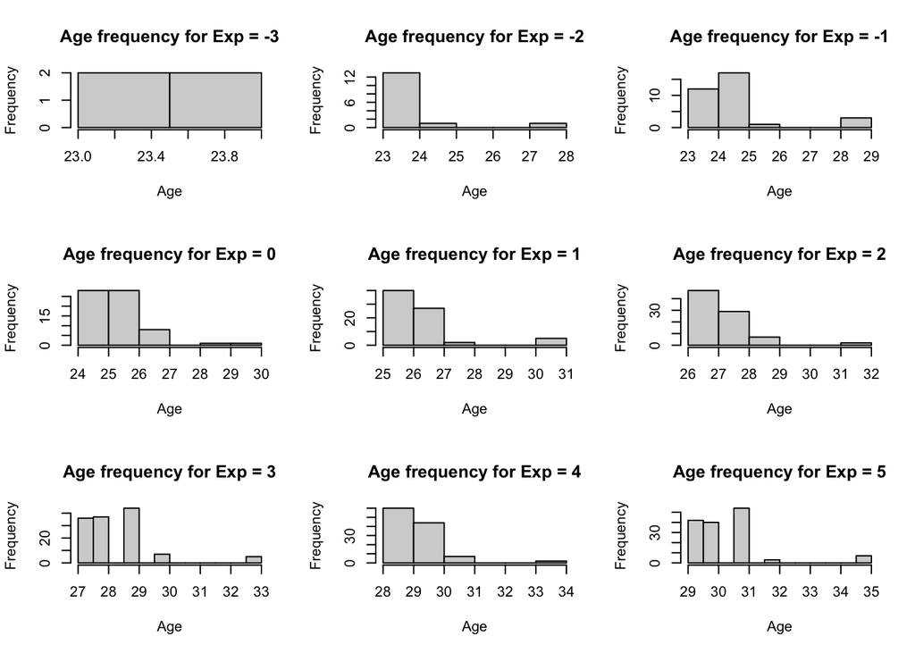

```r
par(mfrow = c(3, 3)) # 3x3 grid for the histograms

# loop iterates over years of experience
for (i in -3:5) {
  # plotting histogram for age distribution with year of experience fixed (using %in%)
  # the sprintf function allows to use the value of a variable inside a string, it is a wrapper for a C function. This is useful for the titles of our plots.
  hist(UniversalBank[Experience %in% i, Age], main =sprintf("Age frequency for Exp = %i", i) , xlab = "Age")
}
```

```r
par(mfrow = c(1, 1)) # going back to normal 1x1 grid for plots
```

We can deduce that the most common age at which people start working is 24 years old. This looks accurate for a population which is getting higher education.

The translation option evoked before is unlikely, as translating everyone by +3 again would mean that the age at which people start working would become 27, and this value seems too high.

Furthermore, we see that people with negative values for experience (-3, -2 and -1) overwhelmingly fall into the 23 and 24 age categories. This distribution indicates that random errors for negative values of experience are unlikely, because we wouldn’t get such a clear age distribution. These 23 and 24 year-olds could very well be students who will enter the workforce in 1, 2 or 3 years.

We choose to follow this hypothesis for the rest of this exercise.

Now, let us check if there are any missing values:

```r
t(t(colSums(is.na(UniversalBank)))) #number of missing values in each column
```

```
##                    [,1]
## ID                    0
## Age                   0
## Experience            0
## Income                0
## ZIP Code              0
## Family                0
## CCAvg                 0
## Education             0
## Mortgage              0
## Personal Loan         0
## Securities Account    0
## CD Account            0
## Online                0
## CreditCard            0
```

Fortunately, there are no missing values!

We can plot the distributions of each variable.

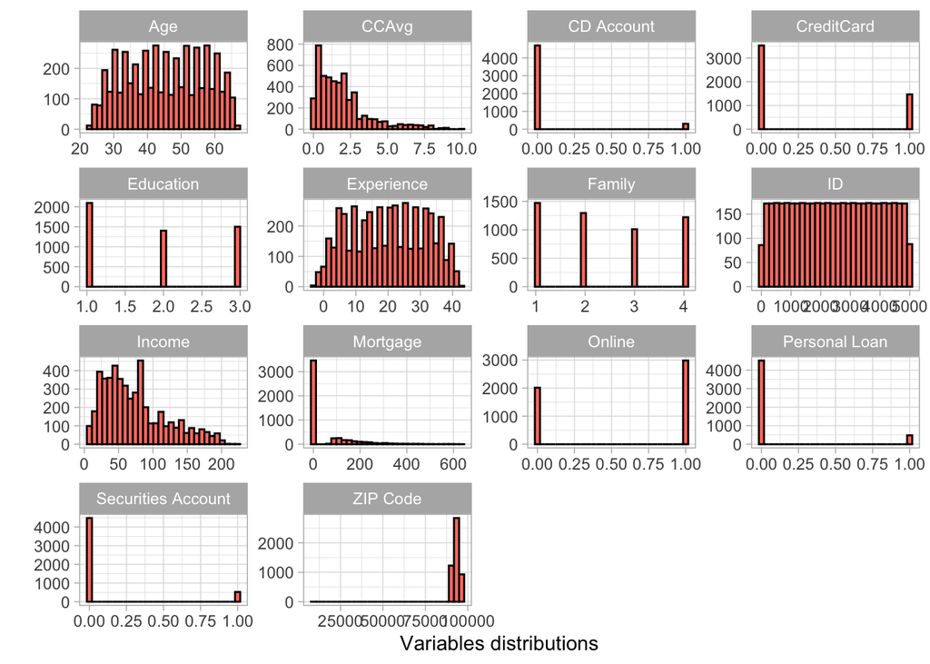

```r
UniversalBank %>% gather() %>%                        # gather transforms data into two columns with "key" and "value"
  ggplot(aes(value)) +                                # plotting the value
  facet_wrap(~ key, scales = "free") +                # making one plot for each key with facet
  geom_histogram(color = "black", fill = "#FA8072") + # making histograms
  theme_light() +                                     # aesthetic theme for our plots
  labs(x = "Variables distributions", y = "")         # label of the figure
```

We have our five dummy variables as well as `Education` and `Family` which take three and four different values respectively. These seven variables all take a few discrete different values. `Education` is surely a categorical variable. `Family`, on the other hand, probably represents the number of people in the family.

However, the maximal number is four, over 5000 observations. Either there are no families bigger than four in this data, or the variable might also be categorical, with the number four representing families of four or more people in the data. For the rest of this exercise. We will consider `Family` as numerical.

The distributions of `ID` and `ZIP Code` aren’t very interesting, since the IDs are uniformly distributed and we already have spotted the outlier in the `ZIP Code` distribution. We plot the histograms for the five remaining distributions in more detail, since the number of bins might have aggregated it too much.

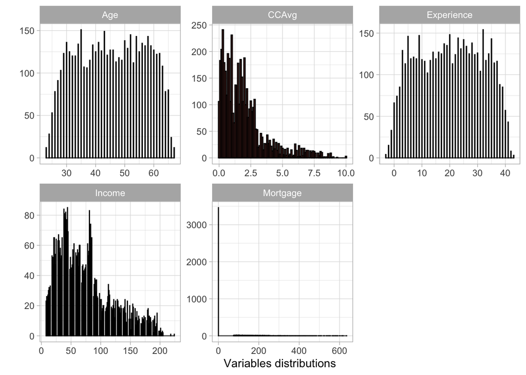

```r
# plotting with the same options as in the previous plot, except we set the width of bins to 0.1 to gain precision
UniversalBank[, c(2,3,4,7,9)] %>% gather() %>%
  ggplot(aes(value)) +
  facet_wrap(~ key, scales = "free") +
  geom_histogram(color = "black", fill = "#FA8072", binwidth = 0.1) +
  theme_light() +
  labs(x = "Variables distributions", y = "")
```

Before we begin, we should convert our categorical variable, `Education`, to dummy variables and split our data into training (60%) and validation (40%) sets.

```r
# we use dummy_cols from the fastDummies package to convert education to dummies
UniversalBank <- dummy_cols(UniversalBank, select_columns = "Education")
#ordering the data table based on ID
setkey(UniversalBank, ID)
# we remove ID, ZIP Code and Education after having created the dummies
UniversalBank <- UniversalBank[, -c(1,5,8)]
# we convert Personal Loan to a factor, as the knn function asks for the variable to predict to be a factor
UniversalBank[, `Personal Loan` := as.factor(`Personal Loan`)]
```

```r
set.seed(111)
# generating training set index
train.index <- as.numeric(sample(row.names(UniversalBank), 0.6*dim(UniversalBank)[1]))
# defining validation set index to be the complementary of training set
valid.index <- as.numeric(setdiff(row.names(UniversalBank), train.index))
# creating two data tables Train and Valid using the indexes
Train <- UniversalBank[train.index, ]
Valid <- UniversalBank[valid.index, ]
# removing the indexes as we won't use them anymore
rm(train.index, valid.index)
```

We also have to scale our training data. The means and standard deviations used to scale `Train` will be used on `Valid` and other new data as well.

```r
# preProcess from the caret package to compute means and sd on Train for scaling
norm.values <- preProcess(Train[, 1:6], method=c("center", "scale"))
# scaling Train and Valid using predict and the scaling values we computed
Train[, 1:6] <- predict(norm.values, Train[, 1:6])
Valid[, 1:6] <- predict(norm.values, Valid[, 1:6])
```

Our data is now ready to perform a $k$-NN algorithm.

# 1 How would this new customer be classified?

We introduce a new customer and scale the appropriate variables of this new customer.

```r
# creating a data table containing the new customer infos
NewCustomer <- data.table("Age" = 40, "Experience" = 10, "Income" = 84, "Family" = 2, "CCAvg" = 2, "Mortgage" = 0, "Securities Account" = 0, "CD Account" = 0, "Online" = 1, "Credit Card" = 1, "Education_1" = 0, "Education_2" = 1, "Education_3" = 0)

# scaling using norm.values as before
NewCustomer[, 1:6] <- predict(norm.values, NewCustomer[, 1:6])
```

We perform a $k$-NN algorithm with $k = 1$ to determine whether or not `NewCustomer` would accept the personal loan.

```r
# performing knn from FNN package
knn(train = Train[,-7], test = NewCustomer, cl = Train$`Personal Loan`, k = 1)
```

```
## [1] 0
## attr(,"nn.index")
##      [,1]
## [1,] 2432
## attr(,"nn.dist")
##           [,1]
## [1,] 0.4825088
## Levels: 0
```

We see that `NewCustomer` is classified at level $0$ by the $1$-NN algorithm, meaning that the customer probably won’t accept the personal loan.

# 2 What is a choice of $k$ that balances between overfitting and ignoring the predictor information?

We will compute the accuracy of the $k$-NN algorithm with respect to $k$.

```r
# initialize a data table with four columns: k, accuracy, accuracy.min and accuracy.max.
Accuracy <- data.table(k = seq(1, 30, 1), accuracy = rep(0, 30), accuracy.min = rep(0, 30), accuracy.max = rep(0, 30))

# compute knn for k from 1 to 30 on validation set
for(i in 1:30) {
  knn.pred <- knn(train = Train[,-7], test = Valid[,-7], cl = Train$`Personal Loan`, k = i)
  # using confusionMatrix to retrieve the accuracy + confidence level
  # storing the values in our Accuracy data table
  Accuracy[i, 2] <- confusionMatrix(knn.pred, Valid$`Personal Loan`)$overall[1]
  Accuracy[i, 3] <- confusionMatrix(knn.pred, Valid$`Personal Loan`)$overall[3]
  Accuracy[i, 4] <- confusionMatrix(knn.pred, Valid$`Personal Loan`)$overall[4]
}
rm(knn.pred, i) #removing the loop objects from environment
```

We can now plot the accuracy with confidence level of 95%:

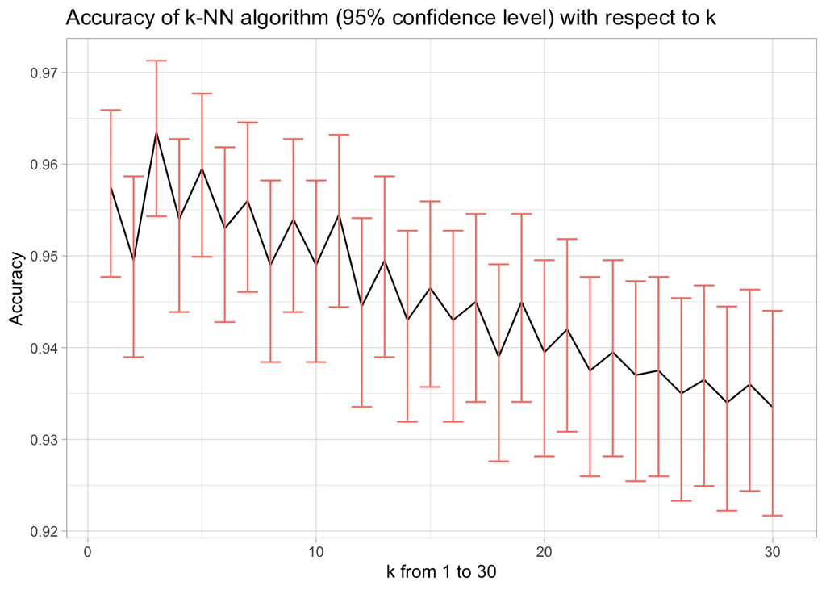

```r
ggplot(data = Accuracy, aes(x = k, y = accuracy)) +                               # plotting Accuracy
  geom_line() +                                                                   # drawing line btw points
  theme_light() +                                                                 # aesthetic theme
  labs(x = "k from 1 to 30", y = "Accuracy", title =                              # labels and title
         "Accuracy of k-NN algorithm (95% confidence level) with respect to k") +
  geom_errorbar(aes(ymin=accuracy.min, ymax=accuracy.max), color = "#FA8072")     # plotting confidence intervals
```

The algorithm is the most accurate for $k = 3$.

# 3 Show the confusion matrix for the validation data that results from using the best $k$.

For $k=3$, the confusion matrix will be

```r
# computing k-NN for k = 3
knn.3 <- knn(train = Train[,-7], test = Valid[,-7], cl = Train$`Personal Loan`, k = 3)
# computing confusion matrix
confusionMatrix(knn.3, Valid$`Personal Loan`)
```

```
## Confusion Matrix and Statistics
##
##           Reference
## Prediction    0    1
##          0 1809   70
##          1    3  118
##
##                Accuracy : 0.9635
##                  95% CI : (0.9543, 0.9713)
##     No Information Rate : 0.906
##     P-Value [Acc > NIR] : < 0.00000000000000022
##
##                   Kappa : 0.745
##
##  Mcnemar's Test P-Value : 0.00000000000001121
##
##             Sensitivity : 0.9983
##             Specificity : 0.6277
##          Pos Pred Value : 0.9627
##          Neg Pred Value : 0.9752
##              Prevalence : 0.9060
##          Detection Rate : 0.9045
##    Detection Prevalence : 0.9395
##       Balanced Accuracy : 0.8130
##
##        'Positive' Class : 0
##
```

```r
rm(knn.3) #removing the variable from the environment once the confusion matrix is computed
```

There are $3$ customers that were identified as susceptible to take a personal loan when in fact, they are not (i.e. $3$ false positives) and $70$ customers which where identified as not susceptible to take a personal loan, when in fact, they are (i.e. $70$ false negatives).

The algorithm is good at preventing pointless advertising (it has a high sensitivity of 99.83%) but it is missing a portion of customers who might be interested (specificity is at 62.77%).

# 4 Classify the customer using the best $k$.

The customer is the same `NewCustomer` as before. We classify them with $k=3$.

```r
# computing k-NN on the new customer
knn(train = Train[,-7], test = NewCustomer, cl = Train$`Personal Loan`, k = 3, prob = TRUE)
```

```
## [1] 0
## attr(,"prob")
## [1] 1
## attr(,"nn.index")
##      [,1] [,2] [,3]
## [1,] 2432 2219 1344
## attr(,"nn.dist")
##           [,1]      [,2]      [,3]
## [1,] 0.4825088 0.4998877 0.6394347
## Levels: 0
```

Again, `NewCustomer` is classified with level $0$, meaning they aren’t susceptible to take a personal loan. We can note that the probability is $1$, meaning that all three neighbors are agreeing with the outcome level.

# 5 Compare the confusion matrix of the test set with that of the training and validation sets. Comment on the differences and their reason.

We repartition our data into training (50%), validation (30%) and test (20%) sets.

```r
# first, we remove Train, Valid and norm.values as we will generate new sets
rm(Train, Valid, norm.values)
# generating training set index
train.index <- as.numeric(sample(row.names(UniversalBank), 0.5*dim(UniversalBank)[1]))
# generating validation set index taken from the complementary of training set
valid.index <- as.numeric(sample(setdiff(row.names(UniversalBank), train.index), 0.3*dim(UniversalBank)[1]))
# defining test set index as complementary of (train.index + valid.index)
test.index <- as.numeric(setdiff(row.names(UniversalBank), union(train.index, valid.index)))
# creating data tables Train, Valid and Test using the indexes
Train <- UniversalBank[train.index, ]
Valid <- UniversalBank[valid.index, ]
Test <- UniversalBank[test.index, ]
# removing indexes as they aren't used anymore
rm(train.index, valid.index, test.index)
```

We need to scale the variables with respect to the training set.

```r
# preProcess from the caret package to compute means and sd on Train for scaling
norm.values <- preProcess(Train[, 1:6], method=c("center", "scale"))
# scaling Train, Valid and Test
Train[, 1:6] <- predict(norm.values, Train[, 1:6])
Valid[, 1:6] <- predict(norm.values, Valid[, 1:6])
Test[, 1:6] <- predict(norm.values, Test[, 1:6])
```

We apply the $k$-NN algorithm with $k=3$ on the training, validation and test sets successively.

```r
# applying k-NN on our 3 sets
knn.3.train <- knn(train = Train[,-7], test = Train[,-7], cl = Train$`Personal Loan`, k = 3)
knn.3.valid <- knn(train = Train[,-7], test = Valid[,-7], cl = Train$`Personal Loan`, k = 3)
knn.3.test <- knn(train = Train[,-7], test = Test[,-7], cl = Train$`Personal Loan`, k = 3)
```

We compute the confusion matrices for each set.

```r
# computing confusion matrices for our 3 k-NN above
confusionMatrix(knn.3.train, Train$`Personal Loan`)
```

```
## Confusion Matrix and Statistics
##
##           Reference
## Prediction    0    1
##          0 2264   60
##          1    2  174
##
##                Accuracy : 0.9752
##                  95% CI : (0.9683, 0.9809)
##     No Information Rate : 0.9064
##     P-Value [Acc > NIR] : < 0.00000000000000022
##
##                   Kappa : 0.8356
##
##  Mcnemar's Test P-Value : 0.000000000000452
##
##             Sensitivity : 0.9991
##             Specificity : 0.7436
##          Pos Pred Value : 0.9742
##          Neg Pred Value : 0.9886
##              Prevalence : 0.9064
##          Detection Rate : 0.9056
##    Detection Prevalence : 0.9296
##       Balanced Accuracy : 0.8714
##
##        'Positive' Class : 0
##
```

```r
confusionMatrix(knn.3.valid, Valid$`Personal Loan`)
```

```
## Confusion Matrix and Statistics
##
##           Reference
## Prediction    0    1
##          0 1355   62
##          1    5   78
##
##                Accuracy : 0.9553
##                  95% CI : (0.9436, 0.9652)
##     No Information Rate : 0.9067
##     P-Value [Acc > NIR] : 0.0000000000007237
##
##                   Kappa : 0.6771
##
##  Mcnemar's Test P-Value : 0.0000000000078374
##
##             Sensitivity : 0.9963
##             Specificity : 0.5571
##          Pos Pred Value : 0.9562
##          Neg Pred Value : 0.9398
##              Prevalence : 0.9067
##          Detection Rate : 0.9033
##    Detection Prevalence : 0.9447
##       Balanced Accuracy : 0.7767
##
##        'Positive' Class : 0
##
```

```r
confusionMatrix(knn.3.test, Test$`Personal Loan`)
```

```
## Confusion Matrix and Statistics
##
##           Reference
## Prediction   0   1
##          0 890  38
##          1   4  68
##
##                Accuracy : 0.958
##                  95% CI : (0.9436, 0.9696)
##     No Information Rate : 0.894
##     P-Value [Acc > NIR] : 0.00000000000013
##
##                   Kappa : 0.7419
##
##  Mcnemar's Test P-Value : 0.00000035428639
##
##             Sensitivity : 0.9955
##             Specificity : 0.6415
##          Pos Pred Value : 0.9591
##          Neg Pred Value : 0.9444
##              Prevalence : 0.8940
##          Detection Rate : 0.8900
##    Detection Prevalence : 0.9280
##       Balanced Accuracy : 0.8185
##
##        'Positive' Class : 0
##
```

Unsurprisingly, the training set gives the best results. Its accuracy is higher (97.52%) and it also has the highest specificity (74.36%).

Overall, sensitivity is always above 99% for all three sets.

The accuracies of validation and test sets are close (95.53% and 95.80% respectively) but we can notice that the test set has a higher specificity (64.15% versus 55.71%).

This might be due to the data partitioning. In fact, there are only 480 customers in total who accepted the personal loan. Here, we can see from the confusion matrices that 234 are in the training set, 140 are in the validation set and 106 are in the test set.

If, by chance, customers in the test set are easier to classify and there are more customers “on the fence” in the validation set, this could lead to a such a difference in specificities. Since 140 and 106 are quite small, these kinds of discrepancies would be more likely to occur.